# Project: Investigating FBI Gun background Check System Data

- Introduction
- Data Wrangling
- Exploratory Data Analysis
- Conclusions

## Introduction

The [data](https://www.google.com/url?q=https://d17h27t6h515a5.cloudfront.net/topher/2017/November/5a0a5623_ncis-and-census-data/ncis-and-census-data.zip&sa=D&ust=1532469042125000) comes from the FBI's National Instant Criminal Background Check System. The NICS is used by to determine whether a prospective buyer is eligible to buy firearms or explosives. Gun shops call into this system to ensure that each customer does not have a criminal record or isn’t otherwise ineligible to make a purchase. The data has been supplemented with state level data from [census.gov](https://www.google.com/url?q=https://www.census.gov/&sa=D&ust=1532469042127000).

- The [NICS data](https://www.google.com/url?q=https://d17h27t6h515a5.cloudfront.net/topher/2017/November/5a0a4db8_gun-data/gun-data.xlsx&sa=D&ust=1532469042127000) is found in one sheet of an .xlsx file. It contains the number of firearm checks by month, state, and type.
- The [U.S. census data](https://www.google.com/url?q=https://d17h27t6h515a5.cloudfront.net/topher/2017/November/5a0a554c_u.s.-census-data/u.s.-census-data.csv&sa=D&ust=1532469042128000) is found in a .csv file. It contains several variables at the state level. Most variables just have one data point per state (2016), but a few have data for more than one year.

Questions I will be focusing on answering:

- How gun trends have changed across states?
- Which features standout for states with highest gun sales?
- Which states have had the highest growth in gun registrations?

```python
# Use this cell to set up import statements for all of the packages that you
#   plan to use.
import numpy as np
import pandas as pd
import matplotlib.pyplot as mp
import seaborn as sb

% matplotlib inline
```

## Data Wrangling

### General Properties

```python
# Load your data and print out a few lines. Perform operations to inspect data
#   types and look for instances of missing or possibly errant data.

# read gun data
gun_df_original = pd.read_excel("gun_data.xlsx")

# Check gun_df shape
gun_df_original.shape
```

```
(12485, 27)
```

```python
# check if there are duplicates
gun_df_original.duplicated().sum()
```

```
0
```

```python
# Check gun_df data
gun_df_original.head(2)
```

|  | month | state | permit | permit_recheck | handgun | long_gun | other | multiple | admin | prepawn_handgun | ... | returned_other | rentals_handgun | rentals_long_gun | private_sale_handgun | private_sale_long_gun | private_sale_other | return_to_seller_handgun | return_to_seller_long_gun | return_to_seller_other | totals |
| --- | --- | --- | --- | --- | --- | --- | --- | --- | --- | --- | --- | --- | --- | --- | --- | --- | --- | --- | --- | --- | --- |
| 0 | 2017-09 | Alabama | 16717.0 | 0.0 | 5734.0 | 6320.0 | 221.0 | 317 | 0.0 | 15.0 | ... | 0.0 | 0.0 | 0.0 | 9.0 | 16.0 | 3.0 | 0.0 | 0.0 | 3.0 | 32019 |
| 1 | 2017-09 | Alaska | 209.0 | 2.0 | 2320.0 | 2930.0 | 219.0 | 160 | 0.0 | 5.0 | ... | 0.0 | 0.0 | 0.0 | 17.0 | 24.0 | 1.0 | 0.0 | 0.0 | 0.0 | 6303 |

2 rows × 27 columns

```python
# Check gun_df summary
gun_df_original.describe()
```

|  | permit | permit_recheck | handgun | long_gun | other | multiple | admin | prepawn_handgun | prepawn_long_gun | prepawn_other | ... | returned_other | rentals_handgun | rentals_long_gun | private_sale_handgun | private_sale_long_gun | private_sale_other | return_to_seller_handgun | return_to_seller_long_gun | return_to_seller_other | totals |
| --- | --- | --- | --- | --- | --- | --- | --- | --- | --- | --- | --- | --- | --- | --- | --- | --- | --- | --- | --- | --- | --- |
| count | 12461.000000 | 1100.000000 | 12465.000000 | 12466.000000 | 5500.000000 | 12485.000000 | 12462.000000 | 10542.000000 | 10540.000000 | 5115.000000 | ... | 1815.000000 | 990.000000 | 825.000000 | 2750.000000 | 2750.000000 | 2750.000000 | 2475.000000 | 2750.000000 | 2255.000000 | 12485.000000 |
| mean | 6413.629404 | 1165.956364 | 5940.881107 | 7810.847585 | 360.471636 | 268.603364 | 58.898090 | 4.828021 | 7.834156 | 0.165591 | ... | 1.027548 | 0.076768 | 0.087273 | 14.936000 | 11.602909 | 1.030182 | 0.402020 | 0.441818 | 0.105987 | 21595.725911 |
| std | 23752.338269 | 9224.200609 | 8618.584060 | 9309.846140 | 1349.478273 | 783.185073 | 604.814818 | 10.907756 | 16.468028 | 1.057105 | ... | 4.386296 | 0.634503 | 0.671649 | 71.216021 | 54.253090 | 4.467843 | 1.446568 | 1.528223 | 0.427363 | 32591.418387 |
| min | 0.000000 | 0.000000 | 0.000000 | 0.000000 | 0.000000 | 0.000000 | 0.000000 | 0.000000 | 0.000000 | 0.000000 | ... | 0.000000 | 0.000000 | 0.000000 | 0.000000 | 0.000000 | 0.000000 | 0.000000 | 0.000000 | 0.000000 | 0.000000 |
| 25% | 0.000000 | 0.000000 | 865.000000 | 2078.250000 | 17.000000 | 15.000000 | 0.000000 | 0.000000 | 0.000000 | 0.000000 | ... | 0.000000 | 0.000000 | 0.000000 | 0.000000 | 0.000000 | 0.000000 | 0.000000 | 0.000000 | 0.000000 | 4638.000000 |
| 50% | 518.000000 | 0.000000 | 3059.000000 | 5122.000000 | 121.000000 | 125.000000 | 0.000000 | 0.000000 | 1.000000 | 0.000000 | ... | 0.000000 | 0.000000 | 0.000000 | 0.000000 | 0.000000 | 0.000000 | 0.000000 | 0.000000 | 0.000000 | 12399.000000 |
| 75% | 4272.000000 | 0.000000 | 7280.000000 | 10380.750000 | 354.000000 | 301.000000 | 0.000000 | 5.000000 | 8.000000 | 0.000000 | ... | 0.000000 | 0.000000 | 0.000000 | 2.000000 | 4.000000 | 0.000000 | 0.000000 | 0.000000 | 0.000000 | 25453.000000 |
| max | 522188.000000 | 116681.000000 | 107224.000000 | 108058.000000 | 77929.000000 | 38907.000000 | 28083.000000 | 164.000000 | 269.000000 | 49.000000 | ... | 64.000000 | 12.000000 | 12.000000 | 1017.000000 | 777.000000 | 71.000000 | 28.000000 | 17.000000 | 4.000000 | 541978.000000 |

8 rows × 25 columns

```python
# Check gun_df null values and columns types
gun_df_original.isnull().sum()
```

```
month                            0
state                            0
permit                          24
permit_recheck               11385
handgun                         20
long_gun                        19
other                         6985
multiple                         0
admin                           23
prepawn_handgun               1943
prepawn_long_gun              1945
prepawn_other                 7370
redemption_handgun            1940
redemption_long_gun           1941
redemption_other              7370
returned_handgun             10285
returned_long_gun            10340
returned_other               10670
rentals_handgun              11495
rentals_long_gun             11660
private_sale_handgun          9735
private_sale_long_gun         9735
private_sale_other            9735
return_to_seller_handgun     10010
return_to_seller_long_gun     9735
return_to_seller_other       10230
totals                           0
dtype: int64
```

```python
gun_df_original.dtypes
```

```
month                         object
state                         object
permit                       float64
permit_recheck               float64
handgun                      float64
long_gun                     float64
other                        float64
multiple                       int64
admin                        float64
prepawn_handgun              float64
prepawn_long_gun             float64
prepawn_other                float64
redemption_handgun           float64
redemption_long_gun          float64
redemption_other             float64
returned_handgun             float64
returned_long_gun            float64
returned_other               float64
rentals_handgun              float64
rentals_long_gun             float64
private_sale_handgun         float64
private_sale_long_gun        float64
private_sale_other           float64
return_to_seller_handgun     float64
return_to_seller_long_gun    float64
return_to_seller_other       float64
totals                         int64
dtype: object
```

```python
# read census data
census_df_original = pd.read_csv("U.S. Census Data.csv")

# Check census_df shape
census_df_original.shape
```

```
(85, 52)
```

```python
# check if there are duplicates
census_df_original.duplicated().sum()
```

```
3
```

```python
# Check census_df data
census_df_original.head(2)
```

|  | Fact | Fact Note | Alabama | Alaska | Arizona | Arkansas | California | Colorado | Connecticut | Delaware | ... | South Dakota | Tennessee | Texas | Utah | Vermont | Virginia | Washington | West Virginia | Wisconsin | Wyoming |
| --- | --- | --- | --- | --- | --- | --- | --- | --- | --- | --- | --- | --- | --- | --- | --- | --- | --- | --- | --- | --- | --- |
| 0 | Population estimates, July 1, 2016, (V2016) | NaN | 4,863,300 | 741,894 | 6,931,071 | 2,988,248 | 39,250,017 | 5,540,545 | 3,576,452 | 952,065 | ... | 865454 | 6651194 | 27,862,596 | 3,051,217 | 624,594 | 8,411,808 | 7,288,000 | 1,831,102 | 5,778,708 | 585,501 |
| 1 | Population estimates base, April 1, 2010, (V2... | NaN | 4,780,131 | 710,249 | 6,392,301 | 2,916,025 | 37,254,522 | 5,029,324 | 3,574,114 | 897,936 | ... | 814195 | 6346298 | 25,146,100 | 2,763,888 | 625,741 | 8,001,041 | 6,724,545 | 1,853,011 | 5,687,289 | 563,767 |

2 rows × 52 columns

```python
# Check census_df summary
census_df_original.describe()
```

|  | Fact | Fact Note | Alabama | Alaska | Arizona | Arkansas | California | Colorado | Connecticut | Delaware | ... | South Dakota | Tennessee | Texas | Utah | Vermont | Virginia | Washington | West Virginia | Wisconsin | Wyoming |
| --- | --- | --- | --- | --- | --- | --- | --- | --- | --- | --- | --- | --- | --- | --- | --- | --- | --- | --- | --- | --- | --- |
| count | 80 | 28 | 65 | 65 | 65 | 65 | 65 | 65 | 65 | 65 | ... | 65 | 65 | 65 | 65 | 65 | 65 | 65 | 65 | 65 | 65 |
| unique | 80 | 15 | 65 | 64 | 64 | 64 | 63 | 64 | 63 | 64 | ... | 65 | 64 | 64 | 64 | 63 | 65 | 65 | 64 | 65 | 64 |
| top | Veteran-owned firms, 2012 | (c) | 53.00% | 7.30% | 50.30% | 50.90% | 6.80% | 3.30% | 0.10% | 51.60% | ... | 16882647 | 0.048 | 50.40% | 2.50% | 1.90% | 84.40% | 13.40% | 1.50% | "55" | 7.10% |
| freq | 1 | 6 | 1 | 2 | 2 | 2 | 2 | 2 | 2 | 2 | ... | 1 | 2 | 2 | 2 | 2 | 1 | 1 | 2 | 1 | 2 |

4 rows × 52 columns

```python
# get list of unique census
census_df_original['Fact'].unique()
```

```
array(['Population estimates, July 1, 2016,  (V2016)',
       'Population estimates base, April 1, 2010,  (V2016)',
       'Population, percent change - April 1, 2010 (estimates base) to July 1, 2016,  (V2016)',
       'Population, Census, April 1, 2010',
       'Persons under 5 years, percent, July 1, 2016,  (V2016)',
       'Persons under 5 years, percent, April 1, 2010',
       'Persons under 18 years, percent, July 1, 2016,  (V2016)',
       'Persons under 18 years, percent, April 1, 2010',
       'Persons 65 years and over, percent,  July 1, 2016,  (V2016)',
       'Persons 65 years and over, percent, April 1, 2010',
       'Female persons, percent,  July 1, 2016,  (V2016)',
       'Female persons, percent, April 1, 2010',
       'White alone, percent, July 1, 2016,  (V2016)',
       'Black or African American alone, percent, July 1, 2016,  (V2016)',
       'American Indian and Alaska Native alone, percent, July 1, 2016,  (V2016)',
       'Asian alone, percent, July 1, 2016,  (V2016)',
       'Native Hawaiian and Other Pacific Islander alone, percent, July 1, 2016,  (V2016)',
       'Two or More Races, percent, July 1, 2016,  (V2016)',
       'Hispanic or Latino, percent, July 1, 2016,  (V2016)',
       'White alone, not Hispanic or Latino, percent, July 1, 2016,  (V2016)',
       'Veterans, 2011-2015', 'Foreign born persons, percent, 2011-2015',
       'Housing units,  July 1, 2016,  (V2016)',
       'Housing units, April 1, 2010',
       'Owner-occupied housing unit rate, 2011-2015',
       'Median value of owner-occupied housing units, 2011-2015',
       'Median selected monthly owner costs -with a mortgage, 2011-2015',
       'Median selected monthly owner costs -without a mortgage, 2011-2015',
       'Median gross rent, 2011-2015', 'Building permits, 2016',
       'Households, 2011-2015', 'Persons per household, 2011-2015',
       'Living in same house 1 year ago, percent of persons age 1 year+, 2011-2015',
       'Language other than English spoken at home, percent of persons age 5 years+, 2011-2015',
       'High school graduate or higher, percent of persons age 25 years+, 2011-2015',
       "Bachelor's degree or higher, percent of persons age 25 years+, 2011-2015",
       'With a disability, under age 65 years, percent, 2011-2015',
       'Persons  without health insurance, under age 65 years, percent',
       'In civilian labor force, total, percent of population age 16 years+, 2011-2015',
       'In civilian labor force, female, percent of population age 16 years+, 2011-2015',
       'Total accommodation and food services sales, 2012 ($1,000)',
       'Total health care and social assistance receipts/revenue, 2012 ($1,000)',
       'Total manufacturers shipments, 2012 ($1,000)',
       'Total merchant wholesaler sales, 2012 ($1,000)',
       'Total retail sales, 2012 ($1,000)',
       'Total retail sales per capita, 2012',
       'Mean travel time to work (minutes), workers age 16 years+, 2011-2015',
       'Median household income (in 2015 dollars), 2011-2015',
       'Per capita income in past 12 months (in 2015 dollars), 2011-2015',
       'Persons in poverty, percent',
       'Total employer establishments, 2015', 'Total employment, 2015',
       'Total annual payroll, 2015 ($1,000)',
       'Total employment, percent change, 2014-2015',
       'Total nonemployer establishments, 2015', 'All firms, 2012',
       'Men-owned firms, 2012', 'Women-owned firms, 2012',
       'Minority-owned firms, 2012', 'Nonminority-owned firms, 2012',
       'Veteran-owned firms, 2012', 'Nonveteran-owned firms, 2012',
       'Population per square mile, 2010',
       'Land area in square miles, 2010', 'FIPS Code', nan,
       'NOTE: FIPS Code values are enclosed in quotes to ensure leading zeros remain intact.',
       'Value Notes', '1', 'Fact Notes', '(a)', '(b)', '(c)',
       'Value Flags', '-', 'D', 'F', 'FN', 'S', 'X', 'Z'], dtype=object)
```

```python
# Check census_df null values and columns types
census_df_original.isnull().sum()
```

```
Fact               5
Fact Note         57
Alabama           20
Alaska            20
Arizona           20
Arkansas          20
California        20
Colorado          20
Connecticut       20
Delaware          20
Florida           20
Georgia           20
Hawaii            20
Idaho             20
Illinois          20
Indiana           20
Iowa              20
Kansas            20
Kentucky          20
Louisiana         20
Maine             20
Maryland          20
Massachusetts     20
Michigan          20
Minnesota         20
Mississippi       20
Missouri          20
Montana           20
Nebraska          20
Nevada            20
New Hampshire     20
New Jersey        20
New Mexico        20
New York          20
North Carolina    20
North Dakota      20
Ohio              20
Oklahoma          20
Oregon            20
Pennsylvania      20
Rhode Island      20
South Carolina    20
South Dakota      20
Tennessee         20
Texas             20
Utah              20
Vermont           20
Virginia          20
Washington        20
West Virginia     20
Wisconsin         20
Wyoming           20
dtype: int64
```

```python
census_df_original.dtypes
```

```
Fact              object
Fact Note         object
Alabama           object
Alaska            object
Arizona           object
Arkansas          object
California        object
Colorado          object
Connecticut       object
Delaware          object
Florida           object
Georgia           object
Hawaii            object
Idaho             object
Illinois          object
Indiana           object
Iowa              object
Kansas            object
Kentucky          object
Louisiana         object
Maine             object
Maryland          object
Massachusetts     object
Michigan          object
Minnesota         object
Mississippi       object
Missouri          object
Montana           object
Nebraska          object
Nevada            object
New Hampshire     object
New Jersey        object
New Mexico        object
New York          object
North Carolina    object
North Dakota      object
Ohio              object
Oklahoma          object
Oregon            object
Pennsylvania      object
Rhode Island      object
South Carolina    object
South Dakota      object
Tennessee         object
Texas             object
Utah              object
Vermont           object
Virginia          object
Washington        object
West Virginia     object
Wisconsin         object
Wyoming           object
dtype: object
```

#### Gun data:

1. Converting month to datetime and rename it to year-month
2. Handling Nulls:
   - Columns with more than half their entries missing will be dropped
   - Premit recheck nulls were replaced by zero
   - Remaining columns nulls were replaced by their column's mean

#### Census data:

1. Dropping duplicated rows
2. Transforming Data so that there would be a column for feature, state and value
3. Cleaning Fact column
   - Change "percent" to % sign
   - Split year if found
4. Ensure correct datatypes are reflected

```python
# After discussing the structure of the data and any problems that need to be
#   cleaned, perform those cleaning steps in the second part of this section.

# make copy to work on
gun_df = gun_df_original

# For gun_df:
# 1- converting Month to date datatype and rename to year-month
gun_df['month'] = pd.to_datetime(gun_df['month'])
gun_df.rename(columns={'month': 'year-month'}, inplace=True)

# confirm datatype conversion & renaming
gun_df.dtypes
```

```
year-month                   datetime64[ns]
state                                object
permit                              float64
permit_recheck                      float64
handgun                             float64
long_gun                            float64
other                               float64
multiple                              int64
admin                               float64
prepawn_handgun                     float64
prepawn_long_gun                    float64
prepawn_other                       float64
redemption_handgun                  float64
redemption_long_gun                 float64
redemption_other                    float64
returned_handgun                    float64
returned_long_gun                   float64
returned_other                      float64
rentals_handgun                     float64
rentals_long_gun                    float64
private_sale_handgun                float64
private_sale_long_gun               float64
private_sale_other                  float64
return_to_seller_handgun            float64
return_to_seller_long_gun           float64
return_to_seller_other              float64
totals                                int64
dtype: object
```

```python
# 2- Manage NULLs, first i will drop columns with missing entries > row_count/2 ..i.e. more than half of the entries are missing

# I found help on how to do it here:
# https://stackoverflow.com/questions/31614804/how-to-delete-a-column-in-pandas-dataframe-based-on-a-condition

# however i modified it a little so that it is applied only from the 5th column onward
gun_df.drop(gun_df.iloc[:, 4:].columns[gun_df.iloc[:, 4:].apply(lambda col: col.isnull().sum() > gun_df.shape[0]/2)],
            axis=1, inplace=True)
```

```python
# check nulls
gun_df.isnull().sum()
```

```
year-month                 0
state                      0
permit                    24
permit_recheck         11385
handgun                   20
long_gun                  19
multiple                   0
admin                     23
prepawn_handgun         1943
prepawn_long_gun        1945
redemption_handgun      1940
redemption_long_gun     1941
totals                     0
dtype: int64
```

```python
# for permit_recheck i will replace nulls with zeros
gun_df['permit_recheck'].fillna(0, inplace=True);

# replace remaining nulls with mean of that column
# found help on how to achieve this from: https://stackoverflow.com/questions/34913590/fillna-in-multiple-columns-in-place-in-python-pandas
gun_df.fillna({'permit': gun_df['permit'].mean(),
               'handgun': gun_df['handgun'].mean(),
               'long_gun': gun_df['long_gun'].mean(),
               'admin': gun_df['admin'].mean(),
               'prepawn_handgun': gun_df['prepawn_handgun'].mean(),
               'prepawn_long_gun': gun_df['prepawn_long_gun'].mean(),
               'redemption_handgun': gun_df['redemption_handgun'].mean(),
               'redemption_long_gun': gun_df['redemption_long_gun'].mean()}, inplace=True)

# check nulls
gun_df.isnull().sum()
```

```
year-month             0
state                  0
permit                 0
permit_recheck         0
handgun                0
long_gun               0
multiple               0
admin                  0
prepawn_handgun        0
prepawn_long_gun       0
redemption_handgun     0
redemption_long_gun    0
totals                 0
dtype: int64
```

```python
# modify totals column to be equal to sum of remaining columns
gun_df['totals'] = gun_df.iloc[:,2:11].sum(axis=1)
```

```python
# make copy of census data to work on
census_df = census_df_original

# for census_df:
# 1- drop duplicates
census_df.drop_duplicates(inplace=True);

# confirm no more duplicates are found
census_df.duplicated().sum()
```

```
0
```

```python
# 2- Transform data so that there would be only 4 coulmns - also take into account that our data is till row 64 only
census_df = census_df.iloc[:64,]
census_df.shape
```

```
(64, 52)
```

```python
# found a way on how to achieve this from:
# https://stackoverflow.com/questions/28654047/pandas-convert-some-columns-into-rows

census_df = census_df.melt(id_vars=["Fact", "Fact Note"],
            var_name="State",
            value_name="Value");
```

```python
# check datetypes of our new transformed df
census_df.State.unique()
```

```
array(['Alabama', 'Alaska', 'Arizona', 'Arkansas', 'California',
       'Colorado', 'Connecticut', 'Delaware', 'Florida', 'Georgia',
       'Hawaii', 'Idaho', 'Illinois', 'Indiana', 'Iowa', 'Kansas',
       'Kentucky', 'Louisiana', 'Maine', 'Maryland', 'Massachusetts',
       'Michigan', 'Minnesota', 'Mississippi', 'Missouri', 'Montana',
       'Nebraska', 'Nevada', 'New Hampshire', 'New Jersey', 'New Mexico',
       'New York', 'North Carolina', 'North Dakota', 'Ohio', 'Oklahoma',
       'Oregon', 'Pennsylvania', 'Rhode Island', 'South Carolina',
       'South Dakota', 'Tennessee', 'Texas', 'Utah', 'Vermont', 'Virginia',
       'Washington', 'West Virginia', 'Wisconsin', 'Wyoming'], dtype=object)
```

```python
# Clean census_df.Value of non-numeric values
census_df.Value.replace('\D+','',regex=True, inplace=True)
census_df.dtypes
```

```
Fact         object
Fact Note    object
State        object
Value        object
dtype: object
```

```python
# convert values column to numeric
census_df['Value'] = pd.to_numeric(census_df['Value'])

# confirm change
census_df.dtypes
```

```
Fact          object
Fact Note     object
State         object
Value        float64
dtype: object
```

```python
# check for nulls
census_df.isnull().sum()
```

```
Fact            0
Fact Note    2400
State           0
Value           7
dtype: int64
```

```python
# fill Value with nulls with zeros
census_df['Value'].fillna(0, inplace=True);

# confirm nulls
census_df.isnull().sum()
```

```
Fact            0
Fact Note    2400
State           0
Value           0
dtype: int64
```

```python
census_df.shape
```

```
(3200, 4)
```

## Exploratory Data Analysis

### Research Question 1 (What is the overall trend of gun purchases?)

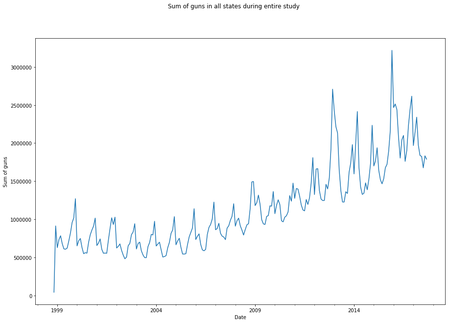

```python
# Use this, and more code cells, to explore your data. Don't forget to add
#   Markdown cells to document your observations and findings.

# sum totals in gun_df by year to get overall trend of gun registration
gun_df.groupby(['year-month'])['totals'].sum().plot(figsize=(15,10));
mp.suptitle('Sum of guns in all states during entire study');
mp.xlabel('Date');
mp.ylabel('Sum of guns');
```

### Research Question 2 (Which states have had the highest growth in gun registrations?)

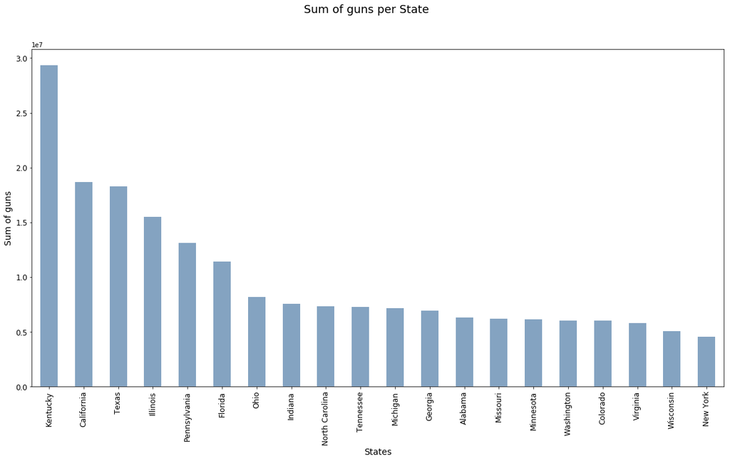

```python
# Continue to explore the data to address your additional research
#   questions. Add more headers as needed if you have more questions to
#   investigate.

# sum totals in gun_df by state to get overall trend of gun registration .. get top 20 countries
# got help on sorting from:
# https://pandas.pydata.org/pandas-docs/stable/reference/api/pandas.DataFrame.sort_values.html

gun_df.groupby(['state'])['totals'].sum().sort_values(ascending=False)[0:20].plot(kind='bar',figsize=(20,10), color=(0.2, 0.4, 0.6, 0.6));
mp.suptitle('Sum of guns per State', fontsize=18);
mp.xlabel('States', fontsize=14);
mp.ylabel('Sum of guns', fontsize=14)
mp.tick_params(axis='both', labelsize=12);
```

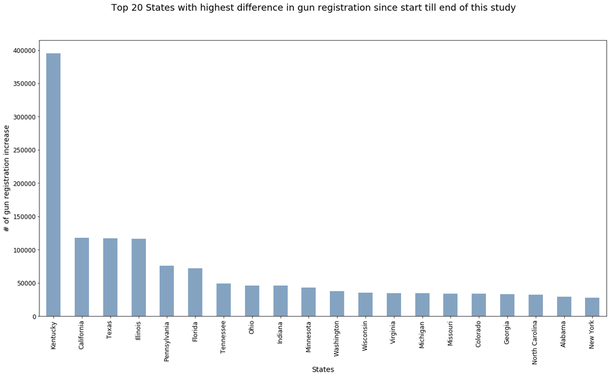

```python
# we now investigate increase of gun registration per state
first_year_data = gun_df[gun_df['year-month']==min(gun_df['year-month'])][['state','totals']]
last_year_data = gun_df[gun_df['year-month']==max(gun_df['year-month'])][['state','totals']]


merged_data = pd.merge(last_year_data, first_year_data,  on='state')
merged_data['difference'] = merged_data['totals_x']-merged_data['totals_y']

merged_data.sort_values(by='difference', ascending=False, inplace=True)

# plot top 20 states which have the highest incearse in gun registration since first data entry till last date
merged_data.groupby(['state'])['difference'].sum().sort_values(ascending=False)[0:20].plot(kind='bar',figsize=(20,10), color=(0.2, 0.4, 0.6, 0.6));
mp.suptitle('Top 20 States with highest difference in gun registration since start till end of this study', fontsize=18);
mp.xlabel('States', fontsize=14);
mp.ylabel('# of gun registration increase', fontsize=14)
mp.tick_params(axis='both', labelsize=12);
```

### Research Question 3 (What census data is most associated with high gun per capita?)

```python
# add a column with idicator of 1 to recognize our top 20 states
census_df['indicator'] = 'blue'

# check if State is in our merged data, if yes, indicator =1
census_df.loc[census_df['State'].isin(merged_data.state.iloc[0:20].unique()), ['indicator']] = 'red'

# confirm changes
census_df.head()
```

|  | Fact | Fact Note | State | Value | indicator |
| --- | --- | --- | --- | --- | --- |
| 0 | Population estimates, July 1, 2016, (V2016) | NaN | Alabama | 4863300.0 | red |
| 1 | Population estimates base, April 1, 2010, (V2... | NaN | Alabama | 4780131.0 | red |
| 2 | Population, percent change - April 1, 2010 (es... | NaN | Alabama | 170.0 | red |
| 3 | Population, Census, April 1, 2010 | NaN | Alabama | 4779736.0 | red |
| 4 | Persons under 5 years, percent, July 1, 2016, ... | NaN | Alabama | 600.0 | red |

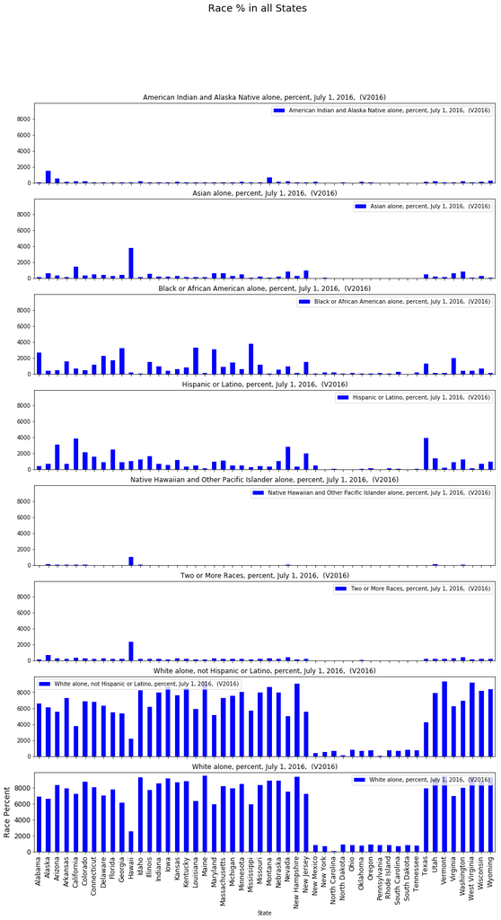

```python
# split census data into groups, like age/race/education/employment factors

# race analysis State per Race

race_filter = ['White alone, percent, July 1, 2016,  (V2016)',
               'Black or African American alone, percent, July 1, 2016,  (V2016)',
               'American Indian and Alaska Native alone, percent, July 1, 2016,  (V2016)',
               'Asian alone, percent, July 1, 2016,  (V2016)',
               'Native Hawaiian and Other Pacific Islander alone, percent, July 1, 2016,  (V2016)',
               'Two or More Races, percent, July 1, 2016,  (V2016)',
               'Hispanic or Latino, percent, July 1, 2016,  (V2016)',
               'White alone, not Hispanic or Latino, percent, July 1, 2016,  (V2016)']

# filter our data by our race filter .. then groupby race & states and sum up values .. finally plot
# got help on muliplot from here: https://stackoverflow.com/questions/45765735/arranging-multiple-for-loop-categorical-plots-with-seaborn

census_df[census_df.Fact.isin(race_filter)].groupby(['State','Fact'])['Value'].sum().sort_values(ascending=False).unstack().plot(kind='bar'
                                                                                                          ,subplots=True
                                                                                                          ,figsize=(15,25)
                                                                                                          ,layout=(8,1)
                                                                                                          ,legend=True
                                                                                                          ,sharey=True
                                                                                                         ,color='blue')

mp.suptitle('Race % in all States', fontsize=18);
mp.ylabel('Race Percent', fontsize=14)
mp.legend()
mp.tick_params(axis='both', labelsize=12);
```

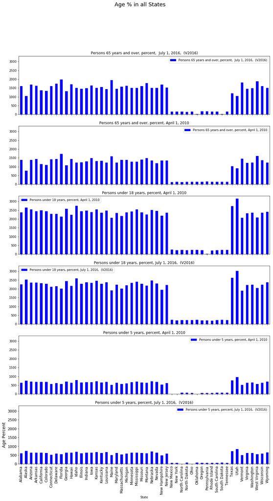

```python
# split census data into groups, like age/race/education/employment factors
# perform same analysis as Race but for age

# age analysis State per Age
age_filter = ['Persons under 5 years, percent, July 1, 2016,  (V2016)',
              'Persons under 5 years, percent, April 1, 2010',
              'Persons under 18 years, percent, July 1, 2016,  (V2016)',
              'Persons under 18 years, percent, April 1, 2010',
              'Persons 65 years and over, percent,  July 1, 2016,  (V2016)',
              'Persons 65 years and over, percent, April 1, 2010']


# filter our data by our age filter .. then groupby race & states and sum up values .. finally plot
census_df[census_df.Fact.isin(age_filter)].groupby(['State','Fact'])['Value'].sum().unstack().plot(kind='bar'
                                                                                                          ,subplots=True
                                                                                                          ,figsize=(15,25)
                                                                                                          ,layout=(6,1)
                                                                                                          ,sharey=True
                                                                                                  ,color='blue')
mp.suptitle('Age % in all States', fontsize=18);
mp.ylabel('Age Percent', fontsize=14)
mp.tick_params(axis='both', labelsize=12);
```

[figure not shown]

```python
# split census data into groups, like age/race/education/employment factors
# perform same analysis as Race & age but for living standards

# view difference between states in 'Per capita income in past 12 months (in 2015 dollars), 2011-2015'
census_df[census_df.Fact == 'Per capita income in past 12 months (in 2015 dollars), 2011-2015'].groupby(['State'])['Value'].sum().sort_values(ascending=False).plot(kind='barh',color=(0.2, 0.4, 0.6, 0.6), figsize=(10,15))
mp.suptitle('Capita income 2011-2015 in Top 20 States', fontsize=18);
mp.ylabel('Capita income', fontsize=14)
mp.legend()
mp.tick_params(axis='both', labelsize=12);
```

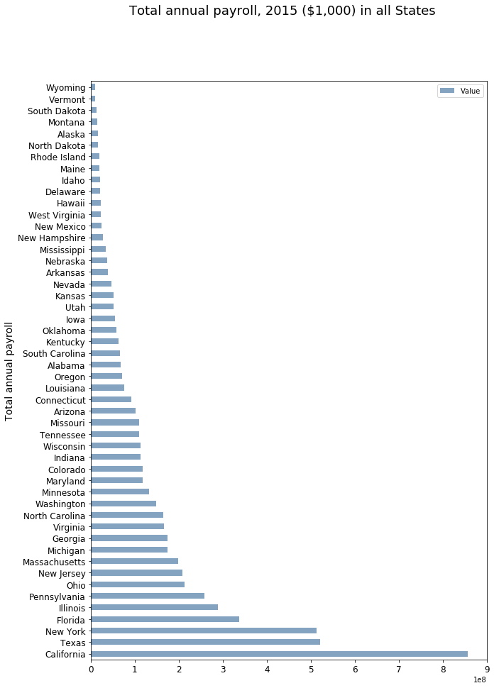

```python
# view difference between states in 'Total annual payroll, 2015 ($1,000)'
census_df[census_df.Fact == 'Total annual payroll, 2015 ($1,000)'].groupby(['State'])['Value'].sum().sort_values(ascending=False).plot(kind='barh',color=(0.2, 0.4, 0.6, 0.6), figsize=(10,15))
mp.suptitle('Total annual payroll, 2015 ($1,000) in all States', fontsize=18);
mp.ylabel('Total annual payroll', fontsize=14)
mp.legend()
mp.tick_params(axis='both', labelsize=12);
```

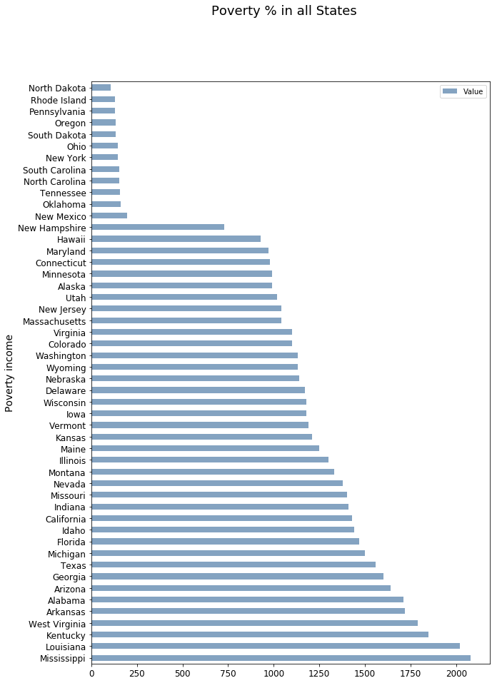

```python
# view difference between states in 'Persons in poverty, percent'
census_df[census_df.Fact == 'Persons in poverty, percent'].groupby(['State'])['Value'].sum().sort_values(ascending=False).plot(kind='barh',color=(0.2, 0.4, 0.6, 0.6), figsize=(10,15))
mp.suptitle('Poverty % in all States', fontsize=18);
mp.ylabel('Poverty income', fontsize=14)
mp.legend()
mp.tick_params(axis='both', labelsize=12);
```

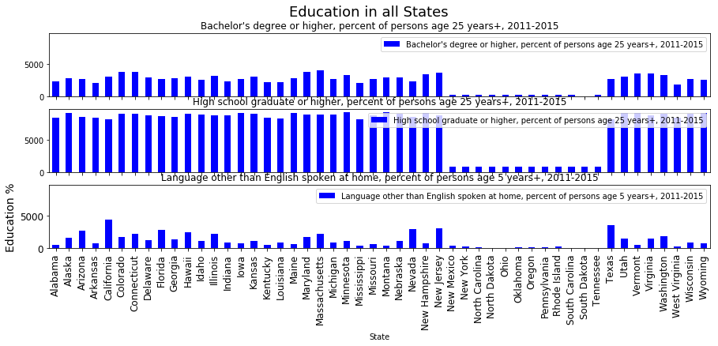

```python
# split census data into groups, like age/race/education/employment factors

# education analysis

education_filter = ['Language other than English spoken at home, percent of persons age 5 years+, 2011-2015',
               'High school graduate or higher, percent of persons age 25 years+, 2011-2015',
               "Bachelor's degree or higher, percent of persons age 25 years+, 2011-2015"]

# filter our data by our education filter .. then groupby race & states and sum up values .. finally plot
# got help on muliplot from here: https://stackoverflow.com/questions/45765735/arranging-multiple-for-loop-categorical-plots-with-seaborn

census_df[census_df.Fact.isin(education_filter)].groupby(['State','Fact'])['Value'].sum().sort_values(ascending=False).unstack().plot(kind='bar'
                                                                                                          ,subplots=True
                                                                                                          ,figsize=(15,5)
                                                                                                          ,layout=(3,1)
                                                                                                          ,legend=True
                                                                                                          ,sharey=True
                                                                                                         ,color='blue')

mp.suptitle('Education in all States', fontsize=18);
mp.ylabel('Education %', fontsize=14)
mp.legend()
mp.tick_params(axis='both', labelsize=12);
```

## Conclusions

1- Data shows there is a growing rate of gun registration

4- Limitations:

- Data discrepencies in-term of collection data is definitely impacting the results.
- Correlation between povery/education and population age and gun ownership would shed extra lights, but sadly this cannot be achieved using the datasets in hand.
- Highlighting gun-group states within all-states charts would have been an excellent way to show where those states lie with respect to the rest, however I was not able to do that as I don't know how.

## Submitting your Project

> Before you submit your project, you need to create a .html or .pdf version of this notebook in the workspace here. To do that, run the code cell below. If it worked correctly, you should get a return code of 0, and you should see the generated .html file in the workspace directory (click on the orange Jupyter icon in the upper left).

> Alternatively, you can download this report as .html via the **File** > **Download as** submenu, and then manually upload it into the workspace directory by clicking on the orange Jupyter icon in the upper left, then using the Upload button.

> Once you've done this, you can submit your project by clicking on the "Submit Project" button in the lower right here. This will create and submit a zip file with this .ipynb doc and the .html or .pdf version you created. Congratulations!

```python
from subprocess import call
call(['python', '-m', 'nbconvert', 'Investigate_a_Dataset.ipynb'])
```